# actividad grupal

Equipo 3

2023-05-01

Alhelí Acosta de la Rosa // A01382195  
Ana Gabriela Sánchez Ruiz // A00828813  
Andrea Natalia Padilla Cedeño // A01197560  
Litzy Duque González // A01382189  
Rodrigo Gutiérrez Del Bosque // A01382212

# 1 Visualización de mapas

## 1.1 Mapa Casos Covid en todo el país

En el siguiente mapa podemos observar la distribución de casos de covid en todo el país, nos pareció interesante que en el sur hay una menor cantidad de casos, por lo que nos concentraremos principalmente en la Zona Sur para determinar aquellos factores socioeconómicos que tengan un efecto en los casos de covid y otros tipos de análisis.

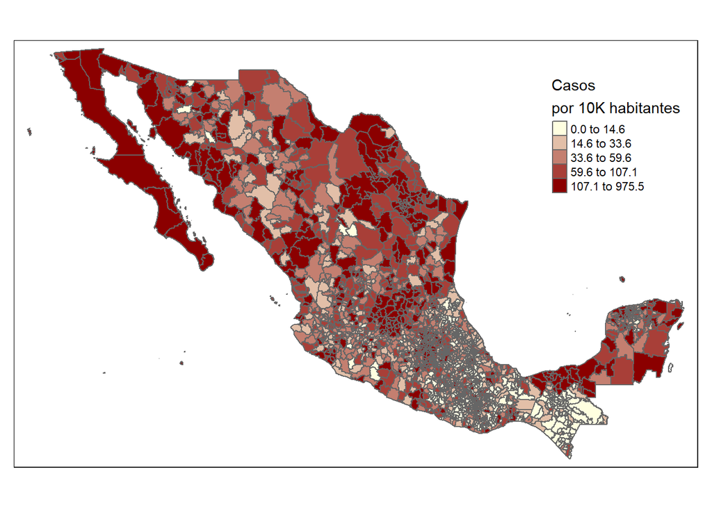

```r
library(tmap)
tm_shape(map_3) +
  tm_polygons("casosx10mil",
              style="quantile",
              palette = c("lightyellow", "darkred"),
              title="\nCasos \npor 10K habitantes")
```

En este mapa podemos observar que existen ciertos estados, en especial la zona norte del país (incluyendo a BC, BCS, NL, COAH) donde parece existir niveles altos de COVID. Es importante que estos son casos reportados, por lo que no significa que realmente haya habido más casos en estas regiones si no que se reportaron más.

## 1.2 Mapeo de Zona Sur

### 1.2.1 Casos Covid

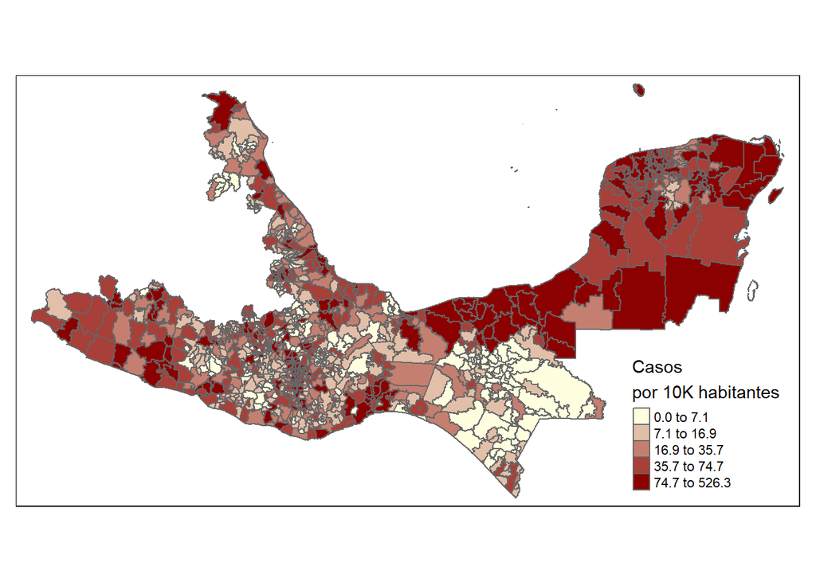

```r
library(tmap)
tm_shape(map_4) +
  tm_polygons("casosx10mil",
              style="quantile",
              palette = c("lightyellow", "darkred"),
              title="\nCasos \npor 10K habitantes")
```

### 1.2.2 Factores socioeconómicos

**Densidad Poblacional**

En el siguiente mapa podemos observar que la mayoría de los estados con mayor densidad poblacional se encuentran en el centro del país, a excepción de algunos outliers en cada estado.

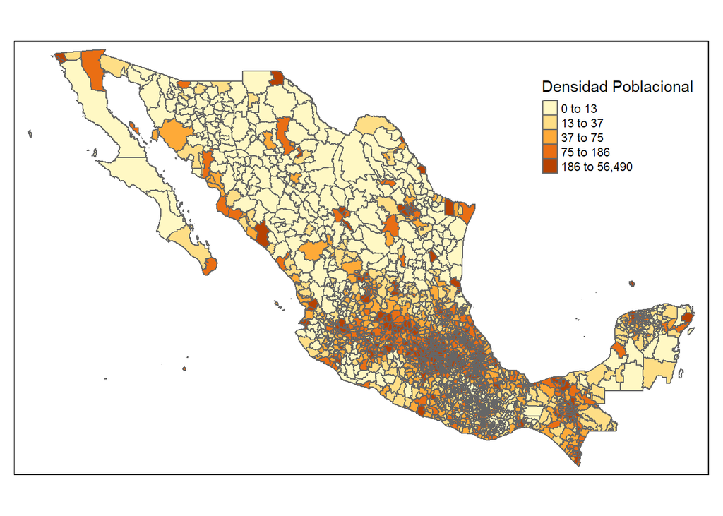

```r
tm_shape(map_3) +
  tm_polygons("popden2020",
              style="quantile",
              title="\nDensidad Poblacional")
```

**Densidad Poblacional - Zona Sur**

En el siguiente mapa podemos observar que la densidad poblacional se centra más en los estados de Veracruz, Tabasco y Chiapas.

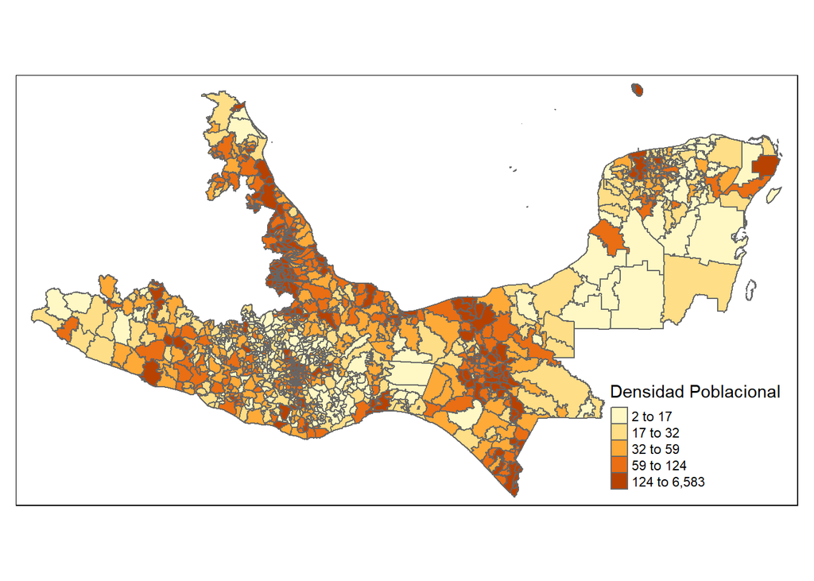

```r
tm_shape(map_4) +
  tm_polygons("popden2020",
              style="quantile",
              title="\nDensidad Poblacional")
```

**Hospitales privados por cada 10,000 habitantes - Zona Sur**

Podemos ver que los estados del Norte y regiones como la CDMX es donde encontramos con un mayor número de hospitales privados. Esto cambia en la zona sur donde estados como Oaxaca y Chiapas cuentan con muy pocos.

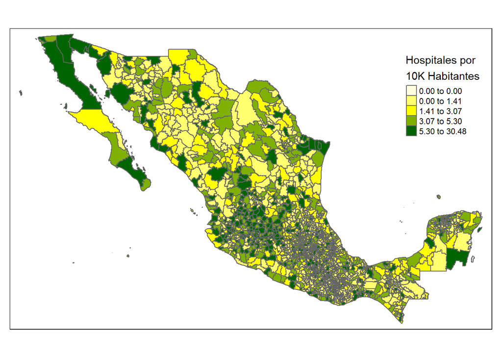

```r
tm_shape(map_3) +
  tm_polygons("hosp_numx10000",
              style="quantile",
              palette = c("lightyellow", "yellow", "darkgreen"),
              title="\nHospitales por \n10K Habitantes")
```

En el siguiente mapa podemos ver que la cantidad de hospitales por cada 10,000 habitantes es mayor en Veracruz, Tabasco, Yucatán y Quintana Roo. Es importante ver que si comparamos este mapa con el de los casos de Covid los estados donde hay más hospitales es también donde hay más casos, lo que puede indicar que en los otros estados la porción de casos reales que eran reportados era menor debido a menos instituciones de salud.

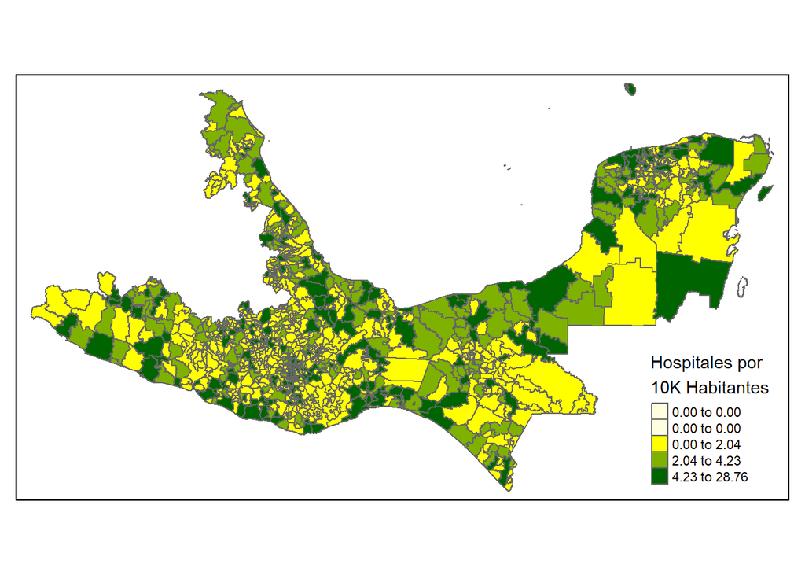

```r
tm_shape(map_4) +
  tm_polygons("hosp_numx10000",
              style="quantile",
              palette = c("lightyellow", "yellow", "darkgreen"),
              title="\nHospitales por \n10K Habitantes")
```

**Rezago Social - Zona Sur**

En cuanto al rezago social, vemos que en general a nivel nacional es en estados del norte y otros como la CDMX donde existe bajo rezago social y que en el sur en su mayoría el rezago es medio - alto.

```
## Variable(s) "rezago_social" contains positive and negative values, so midpoint is set to 0. Set midpoint = NA to show the full spectrum of the color palette.
```

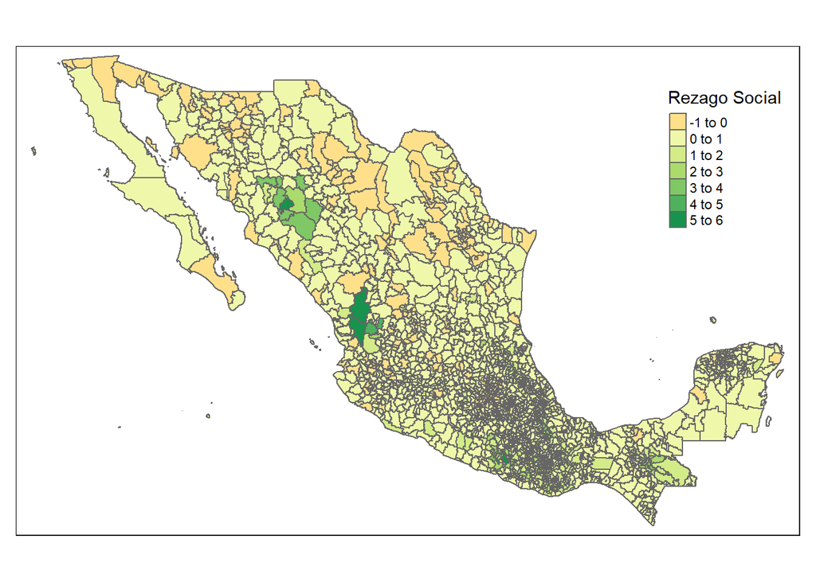

```r
tm_shape(map_3) +
  tm_polygons("rezago_social",
              title="\nRezago Social")
```

En el siguiente mapa podemos observar que el rezago social es mayor en Guerrero, Oaxaca y Chiapas mientras que es menor en Tabasco, Campeche, Yucatán y Quintana Roo. Podemos ver que esto es similar a los estados donde hay más y menos hospitales.

```
## Variable(s) "rezago_social" contains positive and negative values, so midpoint is set to 0. Set midpoint = NA to show the full spectrum of the color palette.
```

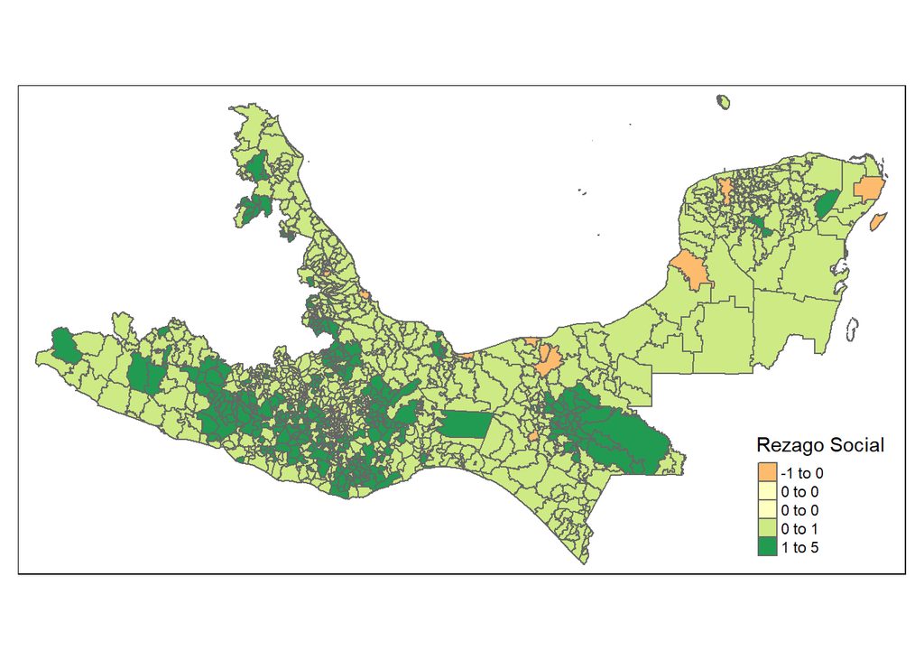

```r
tm_shape(map_4) +
  tm_polygons("rezago_social",
              style="quantile",
              title="\nRezago Social")
```

**Porcentaje de la población que carece de acceso a seguro social - Zona Sur**

En el siguiente mapa podemos observar que el porcentaje de la población que carece de acceso a seguro social es mayor en Guerreo, Oaxaca, Chiapas y Campeche mientras que es menor en Veracruz, Tabasco y Yucatán. De nuevo, esto puede indicar que en ciertos estados los casos no eran descubiertos y/o reportados por falta de instituciones que lo hicieran.

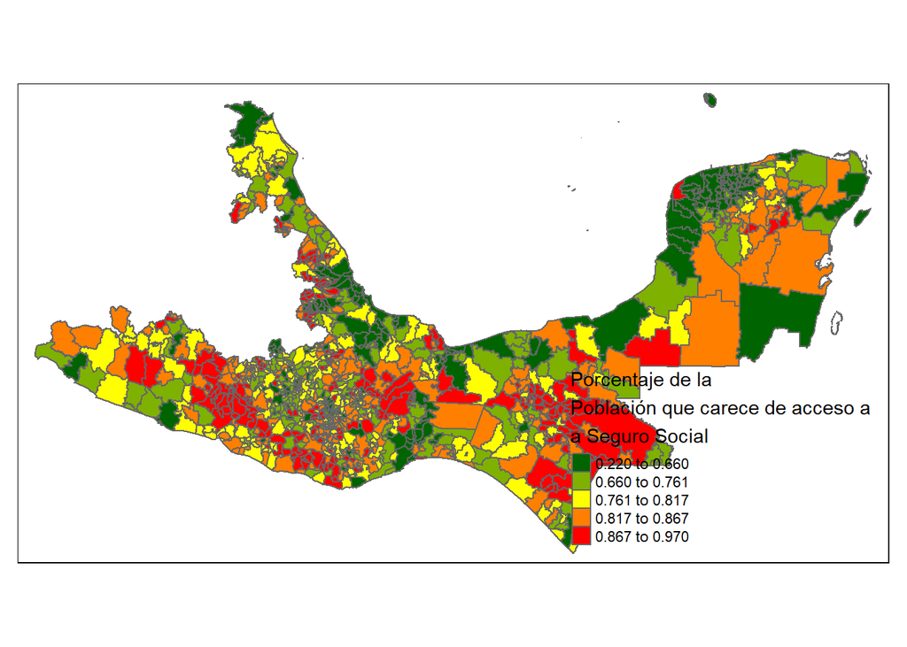

```r
tm_shape(map_4) +
  tm_polygons("porcentaje_pob_acceso_ss",
              style="quantile",
              palette = c("darkgreen","yellow", "red"),
              title="\nPorcentaje de la \nPoblación que carece de acceso a \na Seguro Social")
```

**Porcentaje de hogares que recibieron remesas en 2015 - Zona Sur**

En el siguiente mapa podemos observar que las principales regiones donde hay más población que recibe remesas es en los estados de Guerrero, Oaxaca y Veracruz.

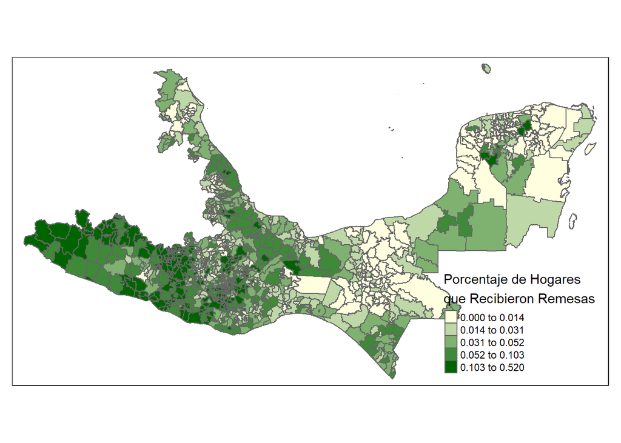

```r
tm_shape(map_4) +
  tm_polygons("hogrem2015",
              style="quantile",
              palette = c("lightyellow","darkgreen"),
              title="\nPorcentaje de Hogares \nque Recibieron Remesas")
```

**Porcentaje de población en situación de pobreza - Zona Sur**

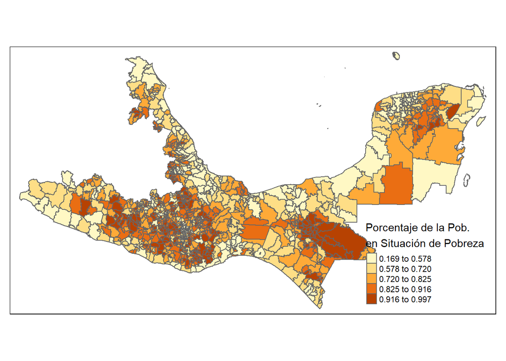

```r
tm_shape(map_4) +
  tm_polygons("porcentaje_pob_pobreza",
              style="quantile",
              title="\nPorcentaje de la Pob. \nen Situación de Pobreza")
```

## 1.3 Clusters

**Nivel Nacional**

**Casos Covid nacional**

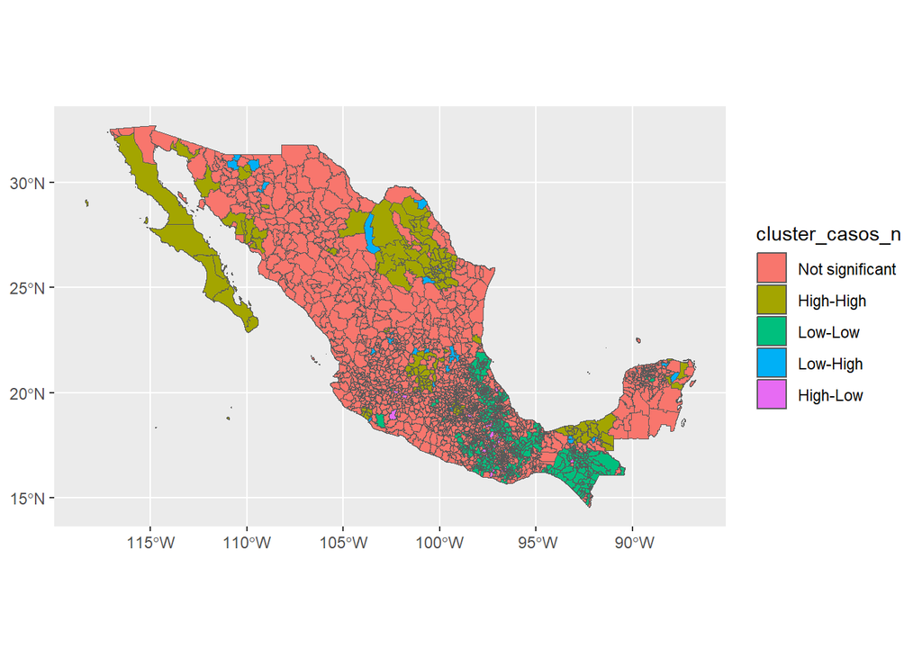

```r
  ggplot(data=map_cluster_n) +
  geom_sf(aes(fill=cluster_casos_n))
```

En este caso podemos ver que a nivel nacional existe en su mayoría poca autocorrelación significativa. Sin embargo, áreas como Coahuila, CDMX y Baja California cuentan con clústers High-High. Por el contrario, algunos estados como Puebla, Oaxaca y Chiapas cuentan con muchos clústers con bajos niveles de covid.

**Densidad Poblacional Nacional**

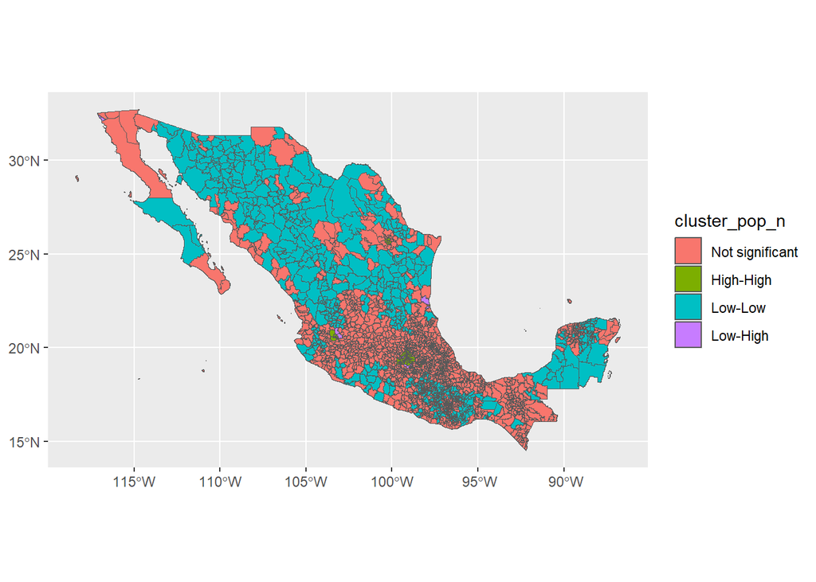

```r
ggplot(data=map_cluster1_n) +
  geom_sf(aes(fill=cluster_pop_n))
```

En este caso podemos ver que la mayoría de los clústers que existen son Low-Low, sobre todo en la zona Norte y en el Sur. En el norte la mayoría de los estados, a excepción de las capitales, son Low-Low. En el sur vemos a estados compo Quintana Roo y Yucatán.

**Acceso a Seguridad Social**

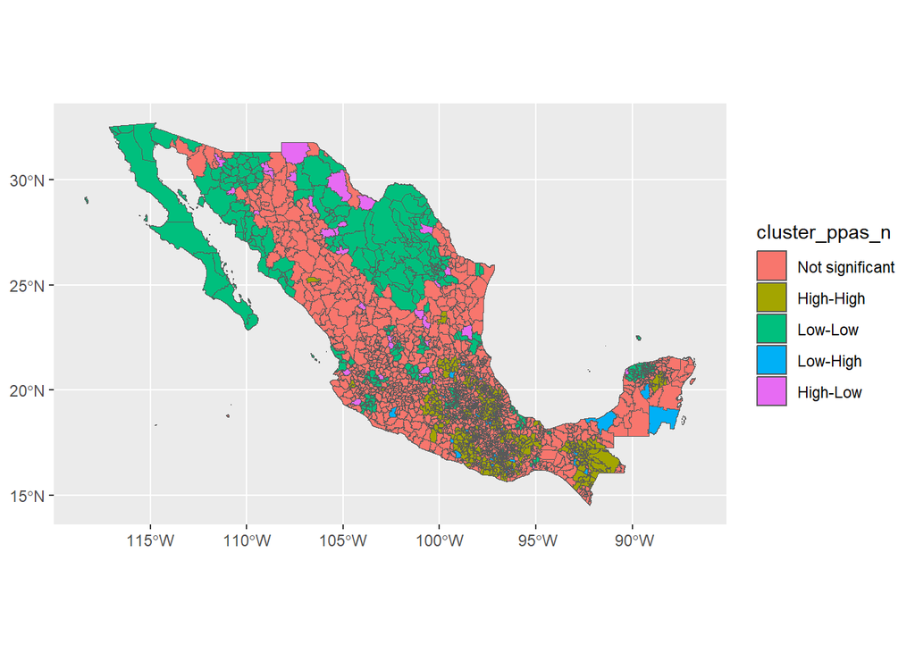

```r
ggplot(data=map_cluster3_n) +
  geom_sf(aes(fill=cluster_ppas_n))
```

En este caso vemos una clara diferencia entre el norte y el centro/sur del país, donde en el norte existen la mayoría de los clústers con mayor acceso a seguridad social. En cuanto a la región estudiada, el sur, vemos que a nivel nacional se relaciona con la región centro a cuanto a que la mayoría de los clústers son High-High.

### 1.3.1 Zona Sur

### 1.3.2 Casos Covid

En el siguiente mapa podemos ver que los clusters principales high-high son cerca de los estados de Tabasco, Campeche y Quintana Roo. Mientras que los clusters no significantes se concentran cerca de los estados de Guerrero, Oaxaca y Veracruz. En cuanto a los clusters Low - Low estos son principalmente en Chiapas. Es importante recordar que, en general, esta región contaba con varios de los clústers Low-Low de covid a nivel nacional, lo contrario a otras regiones como el Noroeste.

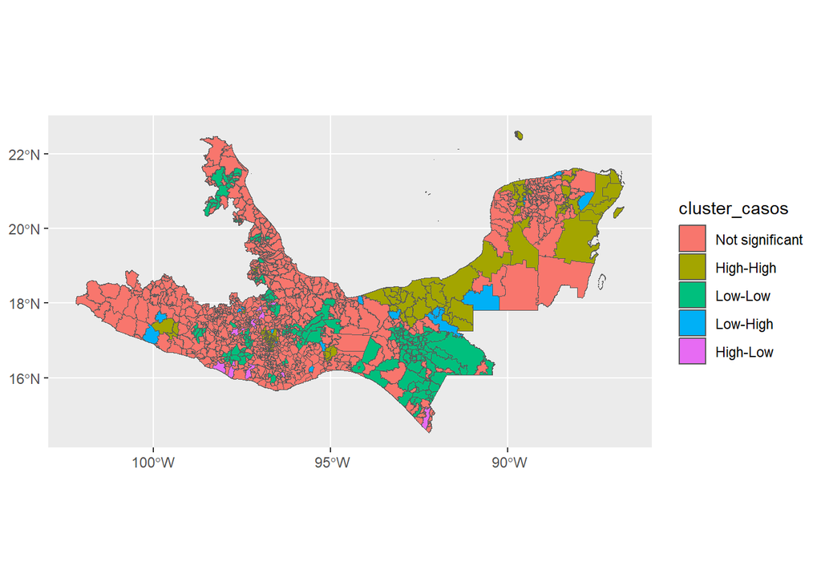

```r
  ggplot(data=map_cluster) +
  geom_sf(aes(fill=cluster_casos))
```

### 1.3.3 Factores Socioeconómicos

**Rezago Social - Zona Sur**

En el siguiente mapa podemos ver que los clusters principales high-high son cerca de los estados de Chiapas y Guerrero. Mientras que los clusters no significantes se concentran cerca de los estados de Veracruz, Tabasco, Campeche, Yucatán y Quintana Roo. Al comparar esto con el cluster de casos vemos que algunos municipios con Low-Low son High-High en Covid, particularmente en Tabasco, Quintana Roo y Campeche. En cuanto a Oaxaca y Chiapas, algunos municipios con Low-Low casos son un cluster con correlación alta de rezago. Esto nos indicaría que en clusters con alto rezago existieron clusters con menos casos reportados y lo mismo en el sentido contrario.

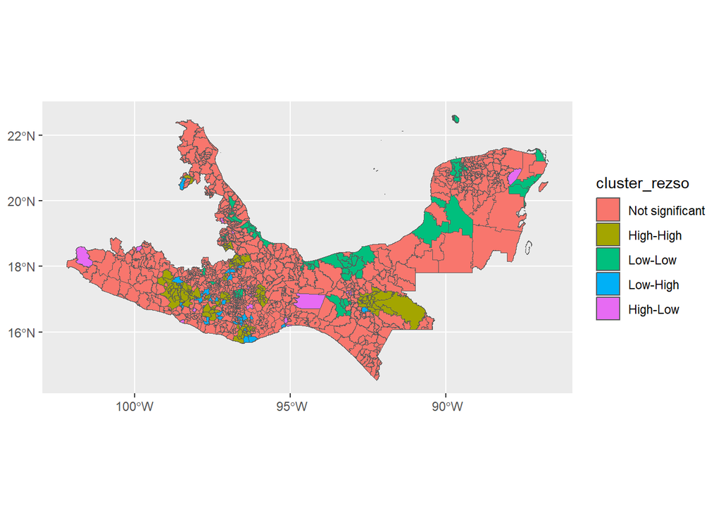

```r
ggplot(data=map_cluster) +
  geom_sf(aes(fill=cluster_rezso))
```

**Densidad Poblacional 2020 - Zona Sur**

En el siguiente mapa podemos ver que los clusters principales low-low son cerca de los estados de Campeche, Yucatán y Quintana Roo. Mientras que los clusters no significantes se concentran cerca de los estados de Tabasco, Chiapas y Veracruz. Vemos que en general se trata de una región con baja densidad poblacional a excepción de municipios como Cancún. Así mismo, esta región contaba con clústers low-low incluso a nivel nacional.

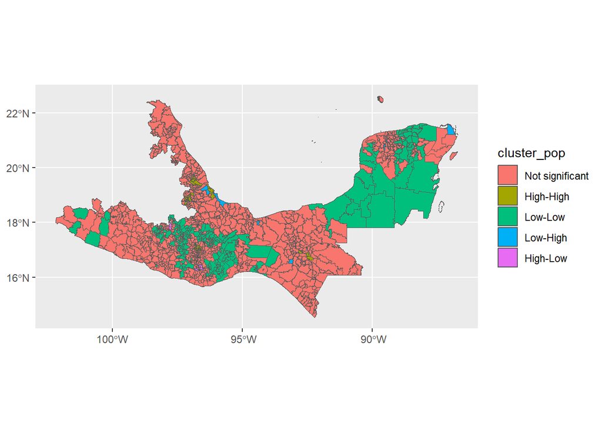

```r
ggplot(data=map_cluster1) +
  geom_sf(aes(fill=cluster_pop))
```

**Porcentaje de población que vive en pobreza - Zona Sur**

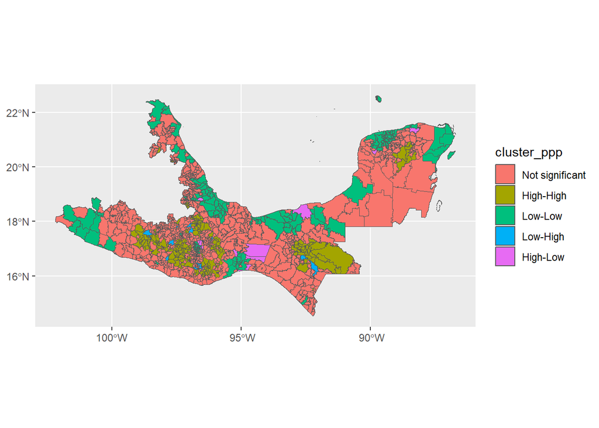

```r
ggplot(data=map_cluster2) +
  geom_sf(aes(fill=cluster_ppp))
```

**Porcentaje de población que carece de acceso a seguridad social - Zona Sur**

En el siguiente mapa podemos ver que los clusters principales high-high son cerca de los estados de Guerrero y Chiapas. Mientras que los clusters no significantes se concentran cerca de los estados de Tabasco, Yucatán, Campeche y Quintana Roo. Parece ser que los estados que cuentan con clusters High de falta de seguridad social cuenta con clusters de menores casos reportados. Esto podría ser debido a que no existen suficientes instituciones para detectar y reportar casos en estos estados. Algo importante fue ver que a nivel nacional casi todos los clústers eran High-High, por lo que la zona a nivel nacional se encuentra por lo general con un menor acceso a estos servicios.

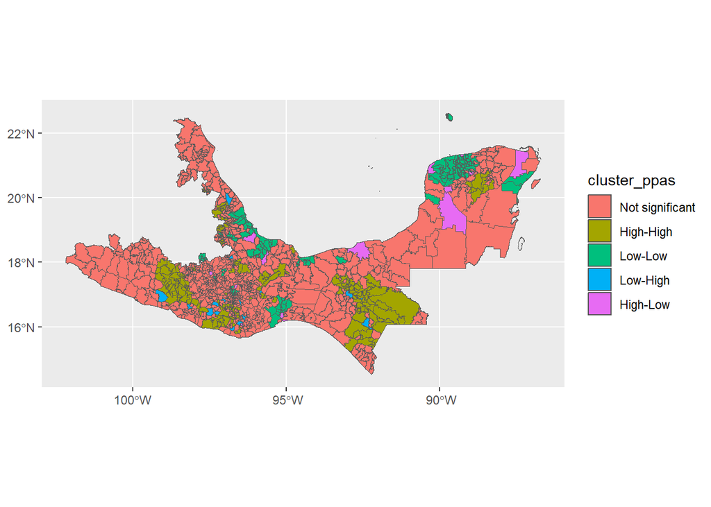

```r
ggplot(data=map_cluster3) +
  geom_sf(aes(fill=cluster_ppas))
```

**Porcentaje de hogares que recibieron remesas en 2015 - Zona Sur**

En el siguiente mapa podemos ver que los clusters principales high-high son cerca del estado de Guerrero, los clusters principales low-low son cerca de los estados de Tabasco, Chiapas y Yucatán. Mientras que los clusters no significantes se concentran cerca de los estados de Veracruz, Campeche y Quintana Roo. Parece que no existe una relación entre esto y los casos de Covid.

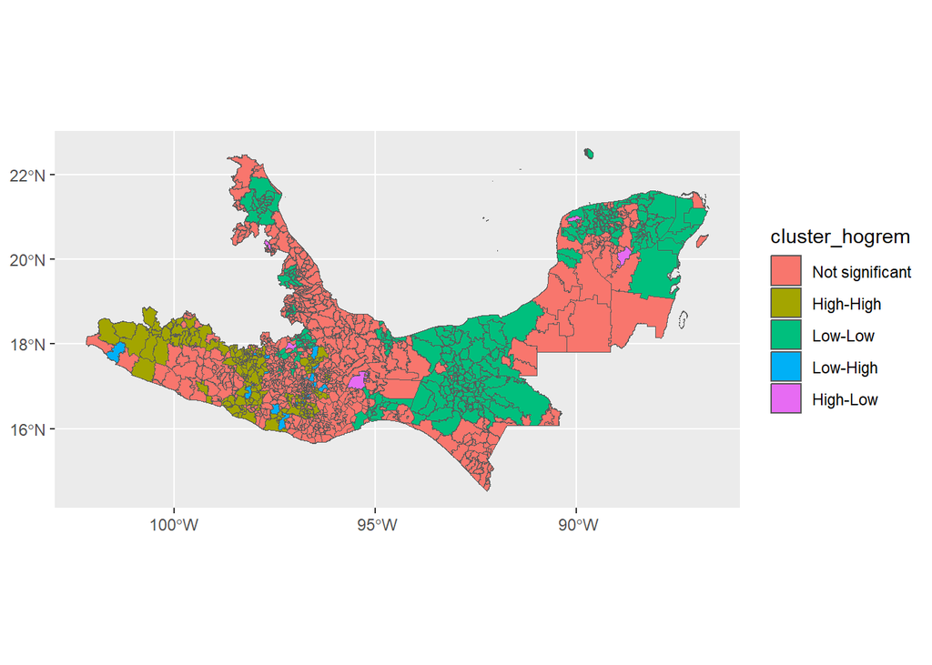

```r
ggplot(data=map_cluster4) +
  geom_sf(aes(fill=cluster_hogrem))
```

# 2 Preguntas de análisis

**1. ¿Cuáles son los principales factores socioeconómicos que propician un incremento / disminución de los casos confrmados de COVID-19?**  
Entre los factores socioeconómicos que afecta si la cantidad de casos de Covid-19 en una localidad aumenta o disminuye, se encuentra el factor de acceso a servicios de salud, cantidad de hospitales y porcentaje de pobreza en la población. A lo largo de este reporte, analizaremos a más detalle cómo cada uno de estos factores influye en los casos de Covid-19 en la zona sur de México.  
**a) ¿Hay factores en municipios cercanos que propicien un incremento / disminución de los casos confrmados de COVID-19 en un municipio en particular?**

El primer factor es “la cantidad de hospitales X10,000 habitantes”, podemos observar que en el estado de Veracruz y Tabasco especialmente en algunos de sus municipios existe una gran diferencia entre la cantidad de hospitales privados. Así mismo podemos observar que en Chiapas, aunque la diferencia no es mucha, hay pocos municipios que tienen mucho más número de hospitales. El estado que se observa más neutral es Quintana Roo. Esto afecta directamente al aumento o disminución del reporte de los casos de Covid.

Así mismo, otro factor es el de la población que “carece de acceso a seguridad social” en donde podemos observar que los estados en los cuales los municipios donde es más notoria la variación es en Guerrero, Oaxaca, Chiapas y Veracruz. Esto tiene sentido ya que son los estados más grandes de la zona sur. Así mismo, son los estados en los que más varía la densidad de población.

Debido a esto es posible que otra variable como el exceso en mortalidad podría ayudar a conocer si sí se trata de que en ciertas regiones los casos no se reportaban. A simple vista estos mapas nos harían creer que a menor nivel de pobreza y rezago los casos aumentan, pero sabemos que puede existir un sesgo en el reporte de los casos. También puede estar relacionado con otras variables como la densidad poblacional, aunque en este caso analizamos una región donde en su mayoría la densidad es menor a la nacional.

También observamos ciertas variables como el porcentaje de hogares que reciben remesas y la densidad poblacional que no fueron lo suficientemente relevantes debido a la falta de clústers o a que los existentes no se relacionaban con los de casos de covid. Esto tiene que ver con la región en específico, ya que a nivel nacional esto cambiaría.  
**2. ¿Qué tipo de factores socioeconómicos regionales pudieran contribuir al crecimiento y/o expansión de organizaciones relacionadas con la prestación de servicios de salud (por ejemplo, hospitales y/o centros privados de atención para la salud)?**  
Como se hacía mención en puntos anteriores, uno de los factores principales que afectan tanto en el número de casos y donde podría se podrían identificar regiones a donde expandirse es la densidad poblacional. No necesariamente lugares en donde solamente hay un mayor número de poblaciónl, si no en regiones donde hay un número de casos alto y una densidad poblacional media, como por ejemplo lo es Chetumal. Muchos de estos destinos se encuentran cerca de áreas metropolitanas o son destinos turísticos, por lo que sería interesante tomar en cuenta aquellas regiones subdesarrolladas que se enncuentran cerca de ciudades grandes o capitales.

Otro factor que podría ser de apoyo para identificar a dónde expandirse es el acceso de las personas a derechos sociales y bienes. Dentro de nuestros clusters pudimos ver cómo se relaciona este factor con el número de casos de covid, sin embargo, es importante ver más a fondo de solo los estados con mayor número de casos. Un ejemplo es Oaxaca donde existe una correlación positiva entre los casos covid y el acceso a derechos sociales, donde su número de casos puede que no sea tan alarmante como en Quintana Roo, pero que tiene un número considerable de casos y se ve afectado por otros factores que van de la mano como el porcentaje de pobreza y los hospitales por cada 10,000 habitantes.

Con esto probamos que no solamente es importante tomar en cuenta a los estados con mayor número de casos para expandirse, ya que probablemente se han detectado esos casos porque sí se tiene ya acceso a servicios de salud privados, si no observar a regiones cerca de los destinos turísticos con alto número de casos o regiones muy cercanas donde igualmente se pudieran ver afectadas por el porcentaje de pobreza.

# 3 Modelos de análisis

**1. Brevemente, describir cómo el análisis espacial de datos se relaciona con la herramienta de inteligencia de negocios “Location Intelligence”.**

Los datos se encuentran en todas partes y cada uno de estos tiende a tener una o se les puede asignar un ubicación es por esto que su relación con location intelligence es en base a la localización la cuales nos ayudará a encontrar patrones y maximizar los datos asociados.

Añadir el factor geográfico a un análisis nos ayuda a entender mejor cómo se comporta cada una de las variables de interés acorde a su región en un mapa, lo cual también puede llevar a la creación de otras hipótesis para la investigación. De igual manera, nos permite evitar la generalización de los datos, y comprender que no todas las variables tienen el mismo comportamiento en cualquier zona geográfica.

```r
#Zona Sur
#Lets split data into training and test sets
# The training set is used to build the model and the test set to evaluate its predictive accuracy.
set.seed(123)
partition <- createDataPartition(y = covid_2$casosx10mil, p=0.7, list=F)
train <- covid_2[partition, ]
test <- covid_2[-partition, ]
```

## 3.1 Modelo de regresión no espacial

2. Especificar y estimar 1 modelo de regresión no espacial.

```r
covid_2lm <- covid_2[c('rezago_social','popden2020','porcentaje_pob_acceso_ss','porcentaje_pob_pobreza','hogrem2015','hosp_numx10000','casosx10mil',"popnoafmed2015", "hogremjefmuj2015" )]
```

```r
lm_model <- lm(casosx10mil ~ ., data = covid_2lm)
summary(lm_model)
```

```
##
## Call:
## lm(formula = casosx10mil ~ ., data = covid_2lm)
##
## Residuals:
##     Min      1Q  Median      3Q     Max
## -153.49  -25.65   -5.84   13.36  453.44
##
## Coefficients:
##                            Estimate Std. Error t value Pr(>|t|)
## (Intercept)               1.682e+02  1.366e+01  12.319  < 2e-16 ***
## rezago_social            -6.237e+00  2.227e+00  -2.801  0.00519 **
## popden2020                2.890e-02  4.089e-03   7.067 2.79e-12 ***
## porcentaje_pob_acceso_ss -4.553e+01  1.474e+01  -3.090  0.00205 **
## porcentaje_pob_pobreza   -1.305e+02  1.486e+01  -8.788  < 2e-16 ***
## hogrem2015               -4.456e+01  1.977e+01  -2.254  0.02438 *
## hosp_numx10000            2.684e+00  4.950e-01   5.423 7.19e-08 ***
## popnoafmed2015           -5.387e+01  2.032e+01  -2.652  0.00813 **
## hogremjefmuj2015          6.289e+01  2.201e+01   2.857  0.00436 **
## ---
## Signif. codes:  0 '***' 0.001 '**' 0.01 '*' 0.05 '.' 0.1 ' ' 1
##
## Residual standard error: 46.06 on 1116 degrees of freedom
## Multiple R-squared:  0.4661, Adjusted R-squared:  0.4623
## F-statistic: 121.8 on 8 and 1116 DF,  p-value: < 2.2e-16
```

```r
test1 <- test
lineal_prediction_test_data <- predict(lm_model,test1)
model_lineal <- rmse(lineal_prediction_test_data, test1$casosx10mil)
model_lineal
```

```
## [1] 48.5801
```

Podemos ver que nos dió un RMSE de 48.58

## 3.2 Modelos de regresión espacial

**3. De acuerdo al ESDA de la Actividad se porqué si / no se justifica el análisis de regresión espacial?** Para esta actividad sí es justificable realizar un análisis exploratorio espacial, podemos percatarnos de que la variable que buscamos analizar que es el número de casos de Covid, su comportamiento puede ser influenciado por distintas variables, una de ellas significante es la ubicación y aspectos relacionados con esta. Sin embargo, para poder analizar este comportamiento a nivel territorial es necesario utilizar el ESDA, no solo para ver la relación entre variables, si no la relación de una variable con la locación.

## 3.3 Especificar y estimar 3 modelos diferentes de regresión espacial.

### 3.3.1 Spatial Error Model con las variables seleccionadas generales

```r
map1 <-map[map$CVE_ENT == 12|map$CVE_ENT == 7|map$CVE_ENT == 27|map$CVE_ENT == 20|map$CVE_ENT == 31|map$CVE_ENT == 4|map$CVE_ENT == 23|map$CVE_ENT == 13,]
lmat4 <- coordinates(map1)
names(lmat4) <- c("lon","lat")
map.centroid4 <- coordinates(map1)
```

```r
map.link_a_queen1<-poly2nb(map_5,queen=T)
map.linkW_a_queen1<-nb2listw(map.link_a_queen1, style="W")
```

Realizaremos un Spatial Error Model para predecir los casos por 10K habitantes. En este caso este modelo no toma valores con lag. En cambio, toma en cuenta los residuales de la variable y de sus vecinos. Esto sirve cuando contamos con una variable explanatoria correlacionada con los vecinos que no ha sido incluida en el modelo.

```r
spatial_error_model <- errorsarlm(casosx10mil ~ rezago_social + popden2020 + I(porcentaje_pob_acceso_ss^2) + porcentaje_pob_pobreza + hogrem2015, data = map_5,
                                  nb2listw(map.link_a_queen1), method="Matrix")
summary(spatial_error_model)
```

```
##
## Call:errorsarlm(formula = casosx10mil ~ rezago_social + popden2020 +
##     I(porcentaje_pob_acceso_ss^2) + porcentaje_pob_pobreza +
##     hogrem2015, data = map_5, listw = nb2listw(map.link_a_queen1),
##     method = "Matrix")
##
## Residuals:
##       Min        1Q    Median        3Q       Max
## -113.6535  -20.2669   -4.6832   11.2307  441.0198
##
## Type: error
## Coefficients: (asymptotic standard errors)
##                                  Estimate  Std. Error  z value  Pr(>|z|)
## (Intercept)                    1.9258e+02  8.3780e+00  22.9867 < 2.2e-16
## rezago_social                 -4.7678e+00  2.3376e+00  -2.0396 0.0413912
## popden2020                     1.9601e-02  3.7443e-03   5.2350 1.650e-07
## I(porcentaje_pob_acceso_ss^2) -4.6453e+01  1.0497e+01  -4.4252 9.634e-06
## porcentaje_pob_pobreza        -1.5563e+02  1.2810e+01 -12.1491 < 2.2e-16
## hogrem2015                    -8.0328e+01  2.1687e+01  -3.7040 0.0002123
##
## Lambda: 0.63874, LR test value: 375.8, p-value: < 2.22e-16
## Asymptotic standard error: 0.029258
##     z-value: 21.832, p-value: < 2.22e-16
## Wald statistic: 476.62, p-value: < 2.22e-16
##
## Log likelihood: -5732.892 for error model
## ML residual variance (sigma squared): 1439.4, (sigma: 37.94)
## Number of observations: 1124
## Number of parameters estimated: 8
## AIC: 11482, (AIC for lm: 11856)
```

En cuanto al AIC, el cual usaremos para comparar con otros modelos, este es de 11,482.

```r
model_spatial1 <- sqrt(mean((map_5$casosx10mil - spatial_error_model$fitted.values)^2))
model_spatial1
```

```
## [1] 37.93964
```

En este caso vemos que el RMSE es de 37.93. Aunque este valor pueda parecer muy alto, lo usaremos para comparar con otros modelos.

### 3.3.2 Spatial Error Model con menos variables

```r
set.seed(123)
```

```r
map_6 <- filter(map_5, CVE_ENT > 0)
```

```r
map1 <-map[map$CVE_ENT == 12|map$CVE_ENT == 7|map$CVE_ENT == 27|map$CVE_ENT == 20|map$CVE_ENT == 31|map$CVE_ENT == 4|map$CVE_ENT == 23|map$CVE_ENT == 13,]
lmat <- coordinates(map1)
names(lmat) <- c("lon","lat")
map.centroid <- coordinates(map1)
```

```r
library(spdep)
library(spatialreg)
```

```r
map.link_a_queen1_1<-poly2nb(map_6,queen=T)
map.linkW_a_queen1_1<-nb2listw(map.link_a_queen1_1, style="W")
```

En este caspo se realizó el mismo procedimiento Spatial Error Model con todas las variables, pero se decidió seleccionar una cantidad menor de variable para poder observar si sale un mejor resultado de RMSE. Como equipo decidimos utilizar las siguientes variables:

```r
spatial_error_model_1 <- errorsarlm(casosx10mil ~  rezago_social + popden2020  + porcentaje_pob_acceso_ss , data = map_6,
                                  nb2listw(map.link_a_queen1_1), method="Matrix")
summary(spatial_error_model_1)
```

```
##
## Call:errorsarlm(formula = casosx10mil ~ rezago_social + popden2020 +
##     porcentaje_pob_acceso_ss, data = map_6, listw = nb2listw(map.link_a_queen1_1),
##     method = "Matrix")
##
## Residuals:
##       Min        1Q    Median        3Q       Max
## -102.6513  -19.4303   -6.3252   11.6783  453.0181
##
## Type: error
## Coefficients: (asymptotic standard errors)
##                             Estimate  Std. Error  z value  Pr(>|z|)
## (Intercept)               1.7294e+02  1.0106e+01  17.1127 < 2.2e-16
## rezago_social            -1.5724e+01  2.2671e+00  -6.9356 4.045e-12
## popden2020                2.4548e-02  3.9667e-03   6.1884 6.078e-10
## porcentaje_pob_acceso_ss -1.6802e+02  1.2649e+01 -13.2837 < 2.2e-16
##
## Lambda: 0.65354, LR test value: 403.83, p-value: < 2.22e-16
## Asymptotic standard error: 0.028553
##     z-value: 22.889, p-value: < 2.22e-16
## Wald statistic: 523.89, p-value: < 2.22e-16
##
## Log likelihood: -5806.88 for error model
## ML residual variance (sigma squared): 1633.4, (sigma: 40.415)
## Number of observations: 1124
## Number of parameters estimated: 6
## AIC: 11626, (AIC for lm: 12028)
```

Donde podemos observar que las variables que más afectan a los casos de Covid es el rezago social y porcentaje de personas que carece de acceso a seguro social ya que se encuentran en números negativos. Por otro lado podemos observar que el AIC es de 11,626.

```r
model_spatial2 <- sqrt(mean((map_6$casosx10mil - spatial_error_model_1$fitted.values)^2))
model_spatial2
```

```
## [1] 40.41529
```

Donde podemos observar que tuvimos un RMSE de 40.41

### 3.3.3 Spatial Autoregressive Model

Ahora se realizará un **Spatial Autoregressive model** para poder observar la relación de la variable predictora que son los casos de covid por cada 10,000 habitantes, con respecto a las variables escogidas considerando el impacto espacial, con esto podremos estimar los parámetros espaciales del modelo para comprender mejor el comportamiento de las variables sobre el número de casos.

```r
spatial_lag_model <- lagsarlm(casosx10mil ~ rezago_social+ popden2020 + porcentaje_pob_acceso_ss +
                     porcentaje_pob_pobreza + hogrem2015,
                              data= map_5, nb2listw(map.link_a_queen1), method="Matrix")
summary(spatial_lag_model)
```

```
##
## Call:lagsarlm(formula = casosx10mil ~ rezago_social + popden2020 +
##     porcentaje_pob_acceso_ss + porcentaje_pob_pobreza + hogrem2015,
##     data = map_5, listw = nb2listw(map.link_a_queen1), method = "Matrix")
##
## Residuals:
##       Min        1Q    Median        3Q       Max
## -121.3600  -20.8114   -4.6594   10.4971  461.0506
##
## Type: lag
## Coefficients: (asymptotic standard errors)
##                             Estimate  Std. Error z value  Pr(>|z|)
## (Intercept)               1.3540e+02  9.2153e+00 14.6931 < 2.2e-16
## rezago_social            -2.0466e+00  2.0442e+00 -1.0012  0.316734
## popden2020                2.1745e-02  3.4443e-03  6.3132 2.733e-10
## porcentaje_pob_acceso_ss -3.9737e+01  1.2642e+01 -3.1433  0.001671
## porcentaje_pob_pobreza   -1.1189e+02  1.1390e+01 -9.8236 < 2.2e-16
## hogrem2015               -2.7367e+01  1.6301e+01 -1.6788  0.093183
##
## Rho: 0.50683, LR test value: 299.38, p-value: < 2.22e-16
## Asymptotic standard error: 0.028931
##     z-value: 17.518, p-value: < 2.22e-16
## Wald statistic: 306.89, p-value: < 2.22e-16
##
## Log likelihood: -5771.173 for lag model
## ML residual variance (sigma squared): 1600.5, (sigma: 40.006)
## Number of observations: 1124
## Number of parameters estimated: 8
## AIC: 11558, (AIC for lm: 11856)
## LM test for residual autocorrelation
## test value: 8.613, p-value: 0.0033376
```

```r
# RMSE
model_spatial_auto <- sqrt(mean((map_5$casosx10mil - spatial_lag_model$fitted.values)^2))
model_spatial_auto
```

```
## [1] 40.00606
```

El RMSE del modelo fue de 40.006, lo que fue muy similar a nuestro resultado del modelo pasado

## 3.4 Modelo de regresión con Machine Learning

5. Especificar y estimar 1 modelo de regresión mediante el uso de machine learning (por ejemplo, support vector machine, decision trees, random forest, XGBoost regression, etc.)

Se realizará un modelo de Random Forest para predecir la variable de casos de covid por cada 10,000 habitantes y ver la importancia de las demás variables para dicha predicción. Podemos ver que el accuracy del modelo para los datos de entrenamiento es de 51%.

```r
random_forest<-randomForest(casosx10mil ~ rezago_social + popden2020 + porcentaje_pob_acceso_ss + porcentaje_pob_pobreza + hogrem2015 + hosp_numx10000, data=train, proximity=TRUE)
print(random_forest)
```

```
##
## Call:
##  randomForest(formula = casosx10mil ~ rezago_social + popden2020 +      porcentaje_pob_acceso_ss + porcentaje_pob_pobreza + hogrem2015 +      hosp_numx10000, data = train, proximity = TRUE)
##                Type of random forest: regression
##                      Number of trees: 500
## No. of variables tried at each split: 2
##
##           Mean of squared residuals: 1899.462
##                     % Var explained: 51.47
```

Al momento de aplicar el modelo a los datos de testing, podemos ver que nos da un RMSE de 45.15%

```r
rf_prediction_test_data <- predict(random_forest,test)
model_random_forest <- rmse(rf_prediction_test_data, test$casosx10mil)
model_random_forest
```

```
## [1] 45.15179
```

Al ver la importancia de las demás variables para predecir los casos de covid, podemos ver en orden de importancia las variables:

- 1. rezago_social
- 2. porcentaje de pobreza
- 3. Porcentaje de población que carece a servicios de seguridad social
- 4. Densidad de población
- 5. Cantidad de hospitales por cada 10,000 personas
- 6. porcentaje de hogares que recibieron remesas durante el año 2015

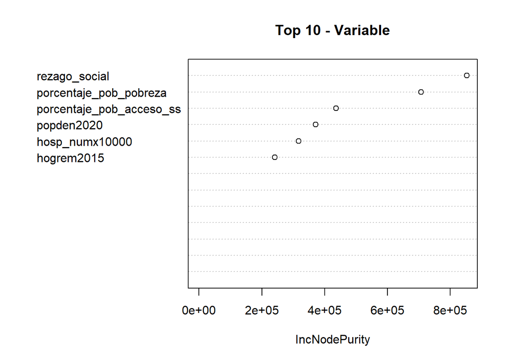

```r
varImpPlot(random_forest, n.var = 13, main = "Top 10 - Variable") # It displays a variable importance plot from the random forest model.
```

Aquí podemos ver la importancia de las variables de igual manera, donde las variables más importantes son las de rezago social y el porcentaje de pobreza.

```r
importance(random_forest)                                         # It is worth mentioning that IncNodePurity by how much the model error increases by dropping each of the specified explanatory variables.
```

```
##                          IncNodePurity
## rezago_social                 852301.7
## popden2020                    371603.4
## porcentaje_pob_acceso_ss      436443.5
## porcentaje_pob_pobreza        706993.0
## hogrem2015                    241006.2
## hosp_numx10000                316689.0
```

## 3.5 Comparación de modelos

**6. Mediante el uso de Root Mean Square Error – RMSE seleccionar 1-2 modelos de regresión anteriores y describir los principales resultados.**

```r
data.table(Lineal = model_lineal,
           Spatial1 = model_spatial1,
           Spatial2 = model_spatial2,
           Spatial3 = model_spatial_auto,
           RandomForest = model_random_forest)
```

```
##     Lineal Spatial1 Spatial2 Spatial3 RandomForest
## 1: 48.5801 37.93964 40.41529 40.00606     45.15179
```

**7. Con base en la situación problema, describir los principales 5-7 hallazgos del análisis de regresión.** - Las variables que predicen de mejor manera los casos de covid son las de rezago social y el porcentaje de personas en situación de pobreza

**8. A partir de los modelos de regresión seleccionados y los hallazgos identificados describir 2-3 sugerencias relacionadas con la toma de decisiones para el crecimiento / expansión territorial de organizaciones orientadas a las prestación de servicios de salud.**